# Machine Learning

Desiré De Waele

15 juli 2016

# Import Packages

```r
library(ElemStatLearn)
library(caret)
library(AppliedPredictiveModeling)
library(caret)
library(forecast)
library(lubridate)
library(e1071)
```

# Question 1

Load the vowel.train and vowel.test data sets from the ElemStatLearn package.

Fit (1) a random forest predictor relating the factor variable y to the remaining variables and (2) a boosted predictor using the “gbm” method. Fit these both with the train() command in the caret package.

What are the accuracies for the two approaches on the test data set? What is the accuracy among the test set samples where the two methods agree?

```r
data(vowel.train)
data(vowel.test)

# Change target to factor variable
vowel.train$y = factor(vowel.train$y)
vowel.test$y = factor(vowel.test$y)

# Train two models, with random forests and boosting
set.seed(33833)
model_tree = train(y ~ ., data = vowel.train, method = 'rf',verbose=FALSE)
model_gbm = train(y ~ ., data = vowel.train, method = 'gbm',verbose=FALSE)

#Get predictions
pred_tree = predict(model_tree, vowel.test)
pred_gbm = predict(model_gbm, vowel.test)

# Get the accuracies
tree_accuracy = sum(pred_tree == vowel.test$y) / length(pred_tree)
gbm_accuracy = sum(pred_gbm == vowel.test$y) / length(pred_tree)

# Get the combined accuracy
agreeSub = vowel.test[pred_tree == pred_gbm,]
pred_comb = predict(model_tree, agreeSub)
comb_accuracy = sum(pred_comb == agreeSub$y) / length(pred_comb)

table(tree_accuracy, gbm_accuracy, comb_accuracy)
```

```
## , , comb_accuracy = 0.638629283489097
##
##                  gbm_accuracy
## tree_accuracy     0.525974025974026
##   0.5995670995671                 1
```

# Question 2

Load the Alzheimer’s data, set the seed to 62433 and predict diagnosis with all the other variables using a random forest (“rf”), boosted trees (“gbm”) and linear discriminant analysis (“lda”) model. Stack the predictions together using random forests (“rf”). What is the resulting accuracy on the test set? Is it better or worse than each of the individual predictions?

```r
# Load the data, create partitions
data(AlzheimerDisease)
adData = data.frame(diagnosis,predictors)
inTrain = createDataPartition(adData$diagnosis, p = 3/4)[[1]]
training = adData[ inTrain,]
testing = adData[-inTrain,]

# Build three models with random forest, boosting and linear discriminant analysis
set.seed(62433)
model_rf = train(diagnosis ~ ., method = 'rf', data = training, verbose=FALSE)
model_gbm = train(diagnosis ~ ., method = 'gbm', data = training, verbose=FALSE)
model_lda = train(diagnosis ~ ., method = 'lda', data = training, verbose=FALSE)

# Get predictions on training data
pred_rf = predict(model_rf, training)
pred_gbm = predict(model_gbm, training)
pred_lda = predict(model_lda, training)

# Build a model with these predictions as predictors
comb_data = data.frame(rf = pred_rf, gbm = pred_gbm, lda = pred_lda, diagnosis = training$diagnosis)
model_comb = train(diagnosis ~ ., method = 'rf', data = comb_data, verbose=FALSE)
# Get predicitons on test data
pred_rf_test = predict(model_rf, testing)
pred_gbm_test = predict(model_gbm, testing)
pred_lda_test = predict(model_lda, testing)
comb_data_test = data.frame(rf = pred_rf_test, gbm = pred_gbm_test, lda = pred_lda_test, diagnosis = testing$diagnosis)
pred_comb_test = predict(model_comb, comb_data_test)

# Compute accuracies
accuracy_rf = sum(pred_rf_test == testing$diagnosis) / length(pred_rf_test)
accuracy_gbm = sum(pred_gbm_test == testing$diagnosis) / length(pred_gbm_test)
accuracy_lda = sum(pred_lda_test == testing$diagnosis) / length(pred_lda_test)
accuracy_comb = sum(pred_comb_test == comb_data_test$diagnosis) / length(pred_comb_test)

table(accuracy_rf, accuracy_gbm, accuracy_lda, accuracy_comb)
```

```
## , , accuracy_lda = 0.878048780487805, accuracy_comb = 0.865853658536585
##
##                    accuracy_gbm
## accuracy_rf         0.865853658536585
##   0.890243902439024                 1
```

# Question 3

Load the concrete data. Set the seed to 233 and fit a lasso model to predict Compressive Strength. Which variable is the last coefficient to be set to zero as the penalty increases?

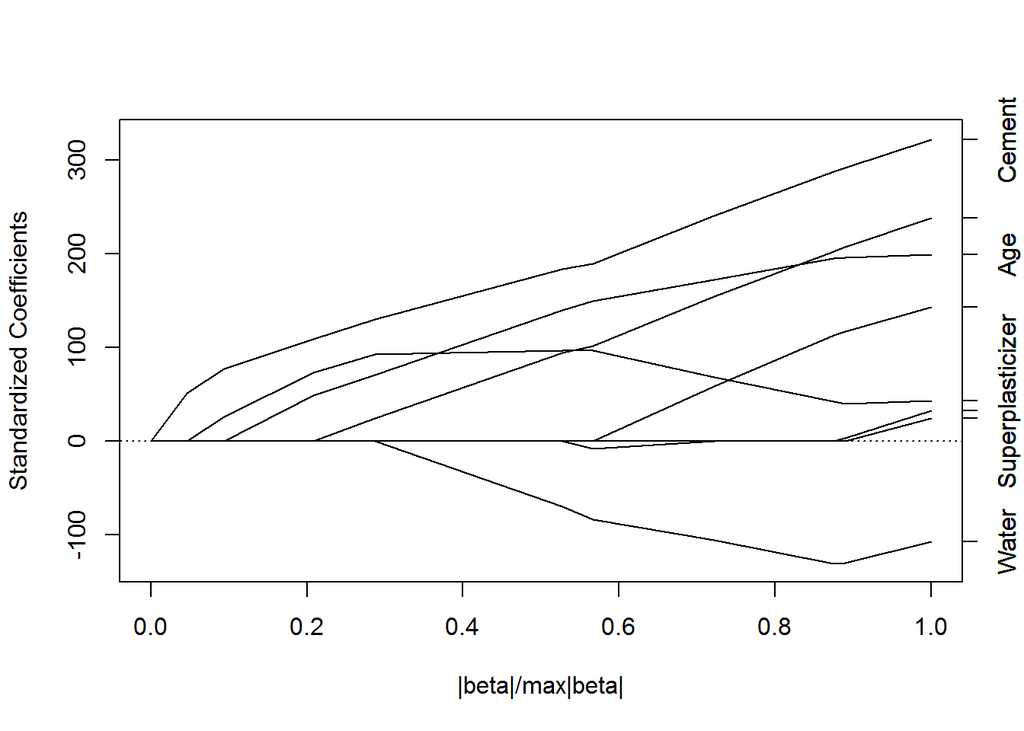

```r
# Load data, create partitions
set.seed(3523)
data(concrete)
inTrain = createDataPartition(concrete$CompressiveStrength, p = 3/4)[[1]]
training = concrete[ inTrain,]
testing = concrete[-inTrain,]

# Build model, plot coefficient paths
set.seed(233)
model = train(CompressiveStrength ~ ., method = 'lasso', data = training)
plot(model$finalModel)
```

# Question 4

Load the data on the number of visitors to the instructors blog from here: https://d396qusza40orc.cloudfront.net/predmachlearn/gaData.csv

Fit a model using the bats() function in the forecast package to the training time series. Then forecast this model for the remaining time points. For how many of the testing points is the true value within the 95% prediction interval bounds?

```r
# Load data, create partitions
dat = read.csv("gaData.csv")
training = dat[year(dat$date) == 2011,]
tstrain = ts(training$visitsTumblr)

remdata = dat[year(dat$date) > 2011,]
tsrem = ts(remdata$visitsTumblr)

# Build model, get predicitons & accuracy
model = bats(tstrain)
pred <- forecast(model, h=length(tsrem),level=c(95))
accuracy(pred, remdata$visitsTumblr)
```

```
##                     ME     RMSE       MAE      MPE     MAPE      MASE
## Training set  10.39787 258.7813  40.22707     -Inf      Inf 0.8437138
## Test set     185.20149 301.2620 205.87807 26.06409 40.76475 4.3180420
##                  ACF1
## Training set 0.012104
## Test set           NA
```

```r
acc = sum(remdata$visitsTumblr <= pred$upper) / nrow(remdata)
print(acc)
```

```
## [1] 0.9617021
```

# Question 5

Load the concrete data. Set the seed to 325 and fit a support vector machine using the e1071 package to predict Compressive Strength using the default settings. Predict on the testing set. What is the RMSE?

```r
# Load data, create partitions
set.seed(3523)
data(concrete)
inTrain = createDataPartition(concrete$CompressiveStrength, p = 3/4)[[1]]
training = concrete[ inTrain,]
testing = concrete[-inTrain,]

# Build a model, get predictions and RMSE
set.seed(325)
model = svm(CompressiveStrength ~ ., data = training)
pred = predict(model, testing)
RMSE = sqrt(sum((pred - testing$CompressiveStrength)^2))

print(RMSE)
```

```
## [1] 107.4401
```